# レポート課題 第4回

氏名：木澤 祐人  
学籍番号：2094572t

ある時系列データに対して，直線近似と多項式近似をそれぞれ実施し，その結果を比較せよ。

Googleドライブのマウントとフォルダ移動

```python
from google.colab import drive
drive.mount('/content/drive')
# フォルダの移動には"%cd"を使用します。
# 作業フォルダへ移動
%cd /content/drive/'My Drive'/情報管理/04/
# 現在のフォルダの中身を表示
%ls
```

```
/content/drive/My Drive/情報管理/04
04_01_single_linear_regression.ipynb    icecream2.csv    test.csv
04_02_multiple_linear_regression.ipynb  icecream.csv     train.csv
convert_report.ipynb                    report_04.ipynb
```

必要ライブラリをインポート。

```python
import pandas as pd
import numpy as np
import matplotlib.pyplot as plt
```

単回帰分析・重回帰分析により回帰係数を求めるための学習データを読み込む。

```python
# 学習データの読み込み
csv_data = pd.read_csv('train.csv', encoding='SHIFT-JIS')
# データの前半部(.headで取得できる)のみ表示
display(csv_data.head())

# numpy用データ(ndarray型) として抽出する。
# 説明変数
X_train = csv_data.loc[:,'x':'x^5'].to_numpy()
# 目的変数
y_train = csv_data.loc[:, 'y'].to_numpy()
```

|  | x | x^2 | x^3 | x^4 | x^5 | y |
| --- | --- | --- | --- | --- | --- | --- |
| 0 | 5 | 25 | 125 | 625 | 3125 | 93.218 |
| 1 | 10 | 100 | 1000 | 10000 | 100000 | 255.877 |
| 2 | 15 | 225 | 3375 | 50625 | 759375 | 269.467 |
| 3 | 20 | 400 | 8000 | 160000 | 3200000 | 287.229 |
| 4 | 25 | 625 | 15625 | 390625 | 9765625 | 264.990 |

x は x軸の値，x^n は xのn乗の値である。

次に，計算した回帰関数を評価するためのテストデータを読み込む

|  | x | x^2 | x^3 | x^4 | x^5 | y |
| --- | --- | --- | --- | --- | --- | --- |
| 0 | 0 | 0 | 0 | 0 | 0 | 193.406 |
| 1 | 1 | 1 | 1 | 1 | 1 | 119.446 |
| 2 | 2 | 4 | 8 | 16 | 32 | 214.537 |
| 3 | 3 | 9 | 27 | 81 | 243 | 172.963 |
| 4 | 4 | 16 | 64 | 256 | 1024 | 179.546 |

```
(40,)
```

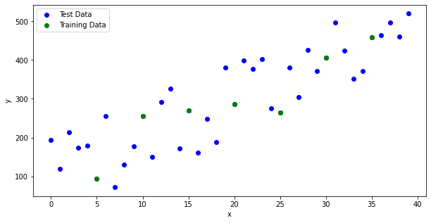

```python
# テストデータの読み込み
csv_data = pd.read_csv('test.csv', encoding='SHIFT-JIS')
# データの前半部(.headで取得できる)のみ表示
display(csv_data.head())

# numpy用データ(ndarray型) として抽出する。
# 説明変数
X_test = csv_data.loc[:,'x':'x^5'].to_numpy()
# 目的変数
y_test = csv_data.loc[:, 'y'].to_numpy()

print(np.shape(y_test))

# 学習データとテストデータをプロット
plt.figure(figsize=(10,5))
plt.scatter(X_test[:,0], y_test, label='Test Data', color='b')
plt.scatter(X_train[:,0], y_train, label='Training Data', color='g')
plt.xlabel('x')
plt.ylabel('y')
plt.legend()
plt.show()
```

# 問1: 直線近似

学習データ `y_train` に対して $y = a*x + b$ という直線関数で近似し，求めた回帰係数 ${\bf a} = [a, b]^{T}$ をテストデータ `X_test` に適用して `y_test` の推定値 `predicted_slr` を求めたい。  
この一連の処理を行うソースコードを以下に記述せよ。

```python
# 単回帰分析を行う関数
def slr(x, y):
  '''
      x: 説明変数
      y: 目的変数
  '''
  N = np.size(x)
  # 係数計算に必要な変数の計算
  xx = x * x
  xy = x * y

  # a と b の計算で共通する分母の計算
  bunbo = N * np.sum(xx) - np.sum(x)*np.sum(x)

  # a および b の計算
  a = (N*np.sum(xy) - np.sum(x)*np.sum(y)) / bunbo
  b = (np.sum(xx)*np.sum(y) - np.sum(xy)*np.sum(x)) / bunbo

  return (a, b)
```

```python
(a, b) = slr(X_train[ : , 0], y_train)
print('regression function: y = %f * x + %f' % (a, b))

tr_predicted_slr = a * X_train[ : , 0] + b
te_predicted_slr = a * X_test[ : , 0] + b
```

```
regression function: y = 9.945729 * x + 91.857429
```

# 問2: 多項式近似

学習データ `y_train` に対して $y = a_1x + a_2x^2 + a_3x^3 + a_4x^4 + a_5x^5 + b$ という5次関数で近似し，求めた回帰係数 ${\bf a} = [a_1, a_2, a_3, a_4, a_5, b]^{T}$ をテストデータ `X_test` に適用して `y_test` の推定値 `predicted_mlr` を求めたい。  
この一連の処理を行うソースコードを以下に記述せよ。

```python
# 重回帰分析を行う
def mlr(x, y):
  '''
      x: 説明変数 [サンプル数, 次元数]の行列
      y: 目的変数 [サンプル数] のベクトル
  '''
  # 単回帰分析にも対応するための処理
  if x.ndim == 1:
    X = np.reshape(x, (-1,1))
  else:
    X = np.array(x)

  # 入力された説明変数のサンプル数と次元数を得る
  (num_samples, num_dimensions) = np.shape(X)

  X = np.concatenate((X, np.ones((num_samples, 1))), axis=1)

  # 重回帰分析の式
  XX = np.dot(X.T, X)
  XXX = np.dot(np.linalg.inv(XX), X.T)
  a = np.dot(XXX, y)

  # a の最後の要素は切片に相当
  b = a[-1]
  # a の最後を除く要素は各説明変数の係数に相当
  a = a[:-1]

  return (a, b)
```

```python
(a, b) = mlr(X_train, y_train)

print('Result of multiple linear regression')
print('y = %f x^5 + %f x^4  + %f x^3 + %f x^2 + %f x + %f' % (a[4], a[3], a[2], a[1], a[0], b))

tr_predicted_mlr = np.dot(X_train, a) + b
te_predicted_mlr = np.dot(X_test, a) + b
```

```
Result of multiple linear regression
y = -0.000341 x^5 + 0.029714 x^4  + -0.866741 x^3 + 8.973838 x^2 + -1.246023 x + -32.824000
```

y について，学習データとテストデータを点で，直線近似`predicted_slr`および多項式近似`predicted_slr`による推定値を線でプロットするコードを以下に記載する。  
問１，２が正しく書けていれば，エラー無くプロットが行えるはずである。

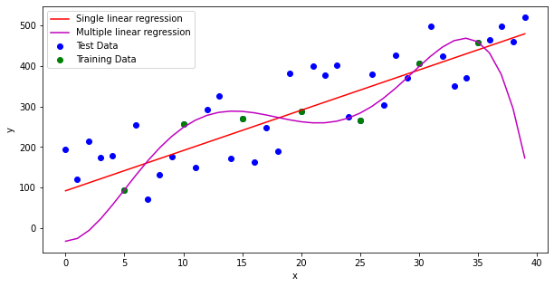

```python
# 学習データとテストデータをプロット
plt.figure(figsize=(10,5))
plt.scatter(X_test[:,0], y_test, label='Test Data', color='b')
plt.scatter(X_train[:,0], y_train, label='Training Data', color='g')
plt.plot(X_test[:,0], te_predicted_slr, label='Single linear regression', color='r')
plt.plot(X_test[:,0], te_predicted_mlr, label='Multiple linear regression', color='m')
plt.xlabel('x')
plt.ylabel('y')
plt.legend()
plt.show()
```

# 問3:（メイン問題）

直線近似および多項式近似による y の推定結果について，  
上記のプロット結果や，学習データに対する推定誤差・相関係数，テストデータに対する推定誤差・相関係数などを見ながら，直線近似と多項式近似の長所・短所について考察せよ。

考察内容を，以下に自由に記述せよ。必要であればソースコードを記述してもよい。

## 考察

学習データ・テストデータ それぞれに対する 単回帰分析・重回帰分析 の結果に関する MSE・RMSE・Correlation coefficient を計算した結果を以下に示す。

```python
# 相関係数を求める関数
def calc_corr_coef(x, y):
  '''
      x, y: 相関を求めたいデータ
  '''
  mu_x = np.mean(x)
  mu_y = np.mean(y)
  std_x = np.std(x)
  std_y = np.std(y)

  corr_coef = np.mean((x - mu_x) * (y - mu_y)) / (std_x * std_y)

  return corr_coef
```

```python
# 学習データ
# 単回帰分析の誤差・相関係数
print("[Training data]\n")
mse = np.mean((y_train - tr_predicted_slr)*(y_train - tr_predicted_slr))
rmse = np.sqrt(mse)
corr_coef = calc_corr_coef(tr_predicted_slr, y_train)
print('Single linear regression')
print('  MSE = %f' % (mse))
print('  RMSE = %f' % (rmse))
print('  Correlation coefficent = %f' % (corr_coef))
print("\n")
# 重回帰分析の誤差・相関係数
mse = np.mean((y_train - tr_predicted_mlr)*(y_train - tr_predicted_mlr))
rmse = np.sqrt(mse)
corr_coef = calc_corr_coef(tr_predicted_mlr, y_train)
print('Multiple linear regression')
print('  MSE = %f' % (mse))
print('  RMSE = %f' % (rmse))
print('  Correlation coefficent = %f' % (corr_coef))

# テストデータ
# 単回帰分析の誤差・相関係数
print("\n\n[Test data]\n")
mse = np.mean((y_test - te_predicted_slr)*(y_test - te_predicted_slr))
rmse = np.sqrt(mse)
corr_coef = calc_corr_coef(te_predicted_slr, y_test)
print('Single linear regression')
print('  MSE = %f' % (mse))
print('  RMSE = %f' % (rmse))
print('  Correlation coefficent = %f' % (corr_coef))
print("\n")
# 重回帰分析の誤差・相関係数
mse = np.mean((y_test - te_predicted_mlr)*(y_test - te_predicted_mlr))
rmse = np.sqrt(mse)
corr_coef = calc_corr_coef(te_predicted_mlr, y_test)
print('Multiple linear regression')
print('  MSE = %f' % (mse))
print('  RMSE = %f' % (rmse))
print('  Correlation coefficent = %f' % (corr_coef))
```

```
[Training data]

Single linear regression
  MSE = 1947.134575
  RMSE = 44.126348
  Correlation coefficent = 0.914074


Multiple linear regression
  MSE = 202.417967
  RMSE = 14.227367
  Correlation coefficent = 0.991414


[Test data]

Single linear regression
  MSE = 4045.611134
  RMSE = 63.605119
  Correlation coefficent = 0.865513


Multiple linear regression
  MSE = 12820.094263
  RMSE = 113.225855
  Correlation coefficent = 0.646695
```

### 各データにおける単回帰分析と重回帰分析の比較

学習データでは、重回帰分析の方が平均の誤差が小さく、相関係数も大きいことから、より高い精度の推定となっていることがわかる。 一方テストデータでは、重回帰分析にすることで平均の誤差が増加し、相関係数は約0.22と大幅に減少しているため、単回帰分析の方がより適切な推定となっていると言える。

### 各分析手法における学習データとテストデータの比較

学習データをもとに行った推定が、テストデータに対してどの程度の正確さで適用できるか分析する。  
単回帰分析・重回帰分析共に精度の悪化がみられる。特に重回帰分析では、テストデータに適用した際誤差が大きく増大し、相関係数も大幅に低下している。今回の学習データを対象とした重回帰分析は、テストデータに対して著しい精度の低下を示し、信頼できる推定であるとは言えない。

### 直線近似と多項式近似の長所と短所

単回帰分析はただ一つの要因、すなわち説明変数によって推定するため視覚的に理解しやすい。その反面、一般に複数の要因が絡み合う物事を正確に説明することは困難である。これに対し、重回帰分析は複数の説明変数を用いた推定を行うことから、より精度の高い推定を行うことができる。  
しかし、説明変数同士の強い相関が原因で陥る「多重共線性」など、複数の情報を考慮するがゆえに生ずる欠点も存在する。また、あるデータの重回帰分析の結果を異なるデータに適用した際、単回帰分析の場合より精度に影響が出やすいことも説明変数の多さに起因するものと考えられる。